# M31WithPhat_20180103

```python
__author__ = 'Knut Olsen <kolsen@noao.edu>' # single string; emails in <>
__version__ = '20180103' # yyyymmdd; version datestamp of this notebook
__datasets__ = ['phat_v2']  # enter used datasets by hand
```

- Disclaimer & attribution
- Imports & setup
- Authentication
- Basic info
- Examine the columns of the PHAT object table
- Make an object density map
- Make depth and color maps
- Do a spatial query and make color-color diagrams and CMDs
- Retrieving time series photometry of select objects
- Resources and references

# Fun with PHAT!

The Panchromatic Hubble Andromeda Treasury (PHAT; PI Dalcanton) is a Hubble Space Telescope Multi-cycle program to map roughly a third of M31's star forming disk, using 6 filters covering from the ultraviolet through the near infrared.

The Data Lab hosts two main tables from PHAT: the version 2 object table (phat_v2.phot_mod) and the version 2 single epoch measurement table (phat_v2.phot_meas). The object table contains average photometry in all filters, with one row per object. The measurement table contains all of the photometric measurements for all objects, with one row per measurement. The measurement table contains ~7.5 billion rows.

In this notebook, we'll use these tables to do some exploration of the PHAT survey.

# Disclaimer & attribution

If you use this notebook for your published science, please acknowledge the following:

- Data Lab concept paper: Fitzpatrick et al., "The NOAO Data Laboratory: a conceptual overview", SPIE, 9149, 2014, http://dx.doi.org/10.1117/12.2057445
- Data Lab disclaimer: http://datalab.noao.edu/disclaimers.php
- PHAT Reduction paper: Williams et al., "Reducing and Analyzing the PHAT Survey with the Cloud", ApJS, 2018, in press

# Imports and setup

```python
import numpy as np
import pylab as plt
import matplotlib
import healpy as hp

%matplotlib inline

# Datalab and related imports
from dl import authClient as ac, queryClient as qc, helpers
```

# Authentication

```python
# Python 2/3 compatibility
try:
    input = raw_input
except NameError:
    pass

# Either get token for anonymous user
token = ac.login('anonymous')
```

# Basic info

First, let's look at the tables available in the PHAT database, and then get some basic information from the Data Lab statistics database (`tbl_stat`) about the main PHAT object table, phat_v2.phot_mod.

```python
try:
    print(qc.schema('phat_v2',format='json',profile='default'))
except Exception as e:
    print(e.message)
```

```
Schema: phat_v2

      Table Name   Description
      ----------   -----------
       phot_meas
        phot_mod
         phot_v2
         star_v2
```

```python
%%time
query = "SELECT * FROM tbl_stat WHERE schema='phat_v2' and tbl_name='phot_mod'" # Retrieve useful stats, quickly
try:
    info = qc.query(token,sql=query) # by default the result is a CSV formatted string
except Exception as e:
    print(e.message)
```

```
CPU times: user 20 ms, sys: 4 ms, total: 24 ms
Wall time: 69.5 ms
```

```python
print(info)
```

```
schema,tbl_name,nrows,ncols,nindex,table_size,indexes_size,total_size
phat_v2,phot_mod,118774088,88,44,43 GB,102 GB,145 GB
```

# Examine the columns of the PHAT object table

First, we'll take a look at some rows from phat_v2.phot_mod, and get all columns.

```python
query = """SELECT *
           FROM phat_v2.phot_mod
           LIMIT 100
        """
```

```python
%%time
try:
    result = qc.query(token,sql=query) # by default the result is a CSV formatted string
except Exception as e:
    print(e.message)
```

```
CPU times: user 23 ms, sys: 2 ms, total: 25 ms
Wall time: 81.2 ms
```

### Convert the output to a Pandas Dataframe

Pandas dataframes are a convenient way to store and work with the data. The Data Lab 'helpers' module ([docs](http://datalab.noao.edu/docs/manual/UsingTheNOAODataLab/ClientInterfaces/Helpers/Helpers.html)) has a conversion method, with many possible output formats.

```python
df1 = helpers.convert(result,'pandas')
print("Number of rows:", len(df1))
print(df1.columns) # print column headings
print(len(df1.columns))
```

```
Returning Pandas dataframe
Number of rows: 100
Index(['ra', 'dec', 'htm9', 'pix256', 'pix4096', 'random_id', 'x', 'y', 'ir_x',
       'ir_y', 'f110w_rate', 'f110w_raterr', 'f110w_vega', 'f110w_err',
       'f110w_chi', 'f110w_snr', 'f110w_sharp', 'f110w_round', 'f110w_crowd',
       'f160w_rate', 'f160w_raterr', 'f160w_vega', 'f160w_err', 'f160w_chi',
       'f160w_snr', 'f160w_sharp', 'f160w_round', 'f160w_crowd', 'f275w_rate',
       'f275w_raterr', 'f275w_vega', 'f275w_err', 'f275w_chi', 'f275w_snr',
       'f275w_sharp', 'f275w_round', 'f275w_crowd', 'f336w_rate',
       'f336w_raterr', 'f336w_vega', 'f336w_err', 'f336w_chi', 'f336w_snr',
       'f336w_sharp', 'f336w_round', 'f336w_crowd', 'f475w_rate',
       'f475w_raterr', 'f475w_vega', 'f475w_err', 'f475w_chi', 'f475w_snr',
       'f475w_sharp', 'f475w_round', 'f475w_crowd', 'f814w_rate',
       'f814w_raterr', 'f814w_vega', 'f814w_err', 'f814w_chi', 'f814w_snr',
       'f814w_sharp', 'f814w_round', 'f814w_crowd', 'f814w_f475w',
       'f475w_f336w', 'f336w_f275w', 'f275w_f160w', 'f160w_f110w',
       'f110w_flag', 'f160w_flag', 'f275w_flag', 'f336w_flag', 'f475w_flag',
       'f814w_flag', 'f275w_gst', 'f336w_gst', 'f475w_gst', 'f814w_gst',
       'f110w_gst', 'f160w_gst', 'inside_ir', 'inside_brick', 'inside_chipgap',
       'inside_other_chipgap', 'field', 'brick', 'objid'],
      dtype='object')
88
```

# Make an object density map

One of the columns in the PHAT object table, pix4096, is the Healpix index (NSIDE=4096, nested scheme) for the objects's RA and Dec. Healpix is a handy tesselation of the sky into tiles of equal area. The Python module healpy has all of the Healpix related functions.

To make maps of aggregate quantities in PHAT, we're going to use the database to return results in a query grouped by Healpix index value. We can then put the results into arrays, and use healpy's functionality to display the maps.

In this first query, the GROUP BY clause tells the database to aggregate the results by the values in the pix4096 column, and return the average RA and Dec of objects in those groups, as well as the pix4096 value itself and the count of the number of objects in the group.

```python
query = """SELECT avg(ra) as ra0,avg(dec) as dec0,pix4096,count(pix4096) as nb
           FROM phat_v2.phot_mod
           GROUP BY pix4096
        """
```

```python
%%time
# This query should take about a minute
try:
    result = qc.query(token,sql=query) # by default the result is a CSV formatted string
except Exception as e:
    print(e.message)
```

```
CPU times: user 29 ms, sys: 1 ms, total: 30 ms
Wall time: 41.6 s
```

### Convert the output to a Pandas Dataframe

```python
df_density = helpers.convert(result,'pandas')
print("Number of rows:", len(df_density))
print(np.sum(df_density['nb'])) # print total counts
```

```
Returning Pandas dataframe
Number of rows: 2574
117335533
```

### Making the Healpix map

A Healpix map is simply a one-dimensional array with number of elements set by the NSIDE parameter, which is the number of times the base Healpixels are split. We can visualize it as a map using the `healpy` library.

```python
hmap = np.zeros(hp.nside2npix(4096))
```

```python
print(df_density.head())
```

```
         ra0       dec0   pix4096     nb
0  11.239025  41.610492  10747797  68020
1  11.294279  41.722430  10747868  63630
2  11.693241  41.890020  10922465  12500
3  11.457172  41.810363  10922601  51534
4  11.843336  42.047941  10923119  22544
```

### Populating the Healpix map

Now we set the elements of our Healpix map to the number of objects returned by the query, calculate the center of the RA and Dec distribution of the objects, and use healpy's gnomview to visualize the output. Notice anything funny? The PHAT object table has duplicate objects between some of the bricks (bricks 11, 12, 13, and 14).

```python
hmap[df_density['pix4096']]=df_density['nb']
(rarot,decrot)=(np.median(df_density['ra0']),np.median(df_density['dec0']))
```

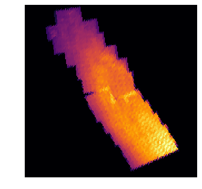

```python
hp.gnomview(hmap,title='',notext=True,cbar=False,reso=0.4,nest=True,rot=(rarot,decrot,0),cmap='inferno',min=1e3,max=8e4)
```

# Make depth and color maps

```python
query = """SELECT avg(ra) as ra0,avg(dec) as dec0,pix4096,count(pix4096) as nb,
            avg(f475w_vega) as gmag,avg(f814w_vega) as imag,avg(brick) as brick,
            avg(f475w_vega-f814w_vega) as g_i
           FROM phat_v2.phot_mod
           WHERE f475w_gst=1 AND f814w_gst=1 AND f475w_vega<50 AND f814w_vega<50
           GROUP BY pix4096
          """
print(query)
```

```
SELECT avg(ra) as ra0,avg(dec) as dec0,pix4096,count(pix4096) as nb,
            avg(f475w_vega) as gmag,avg(f814w_vega) as imag,avg(brick) as brick,
            avg(f475w_vega-f814w_vega) as g_i
           FROM phat_v2.phot_mod
           WHERE f475w_gst=1 AND f814w_gst=1 AND f475w_vega<50 AND f814w_vega<50
           GROUP BY pix4096
```

```python
%%time
# Query will take 1 - 2 minutes
try:
    result = qc.query(token,sql=query) # by default the result is a CSV formatted string
except Exception as e:
    print(e.message)
```

```
CPU times: user 171 ms, sys: 10 ms, total: 181 ms
Wall time: 1min 29s
```

```python
df_all = helpers.convert(result,'pandas')
print("Number of rows:", len(df_all))
print(np.sum(df_all['nb'])) # print total counts
```

```
Returning Pandas dataframe
Number of rows: 2574
81469723
```

```python
print(df_all.head())
```

```
         ra0       dec0   pix4096     nb       gmag       imag      brick  \
0  11.238961  41.610199  10747797  42598  26.615453  24.934838  10.085027
1  11.294243  41.722467  10747868  43786  26.615977  24.997110  12.447312
2  11.693173  41.890007  10922465   7543  27.030190  25.735297  18.000000
3  11.456964  41.810426  10922601  34910  26.747490  25.257324  15.918763
4  11.842830  42.048000  10923119  11078  26.964323  25.645896  20.000000

        g_i
0  1.680615
1  1.618867
2  1.294892
3  1.490165
4  1.318427
```

### Healpix map of average F475W magnitude

The map of the average F475W magnitude gives a good idea of how the PHAT catalog depth varies with position in M31. The depth is much shallower in the Bulge, which is very crowded, than in the outer disk.

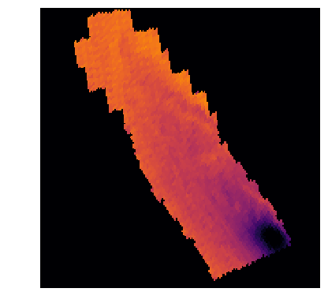

```python
gmap = np.zeros(hp.nside2npix(4096))
gmap[df_all['pix4096']] = df_all['gmag']
hp.gnomview(gmap,title='',notext=True,cbar=False,reso=0.4,nest=True,rot=(rarot,decrot,0),cmap='inferno',min=25,max=28)
```

### Healpix map of average F475W-F814W color

The map of average color reveals both population differences and the dust lanes in the galaxy, as well as the 10 kpc ring.

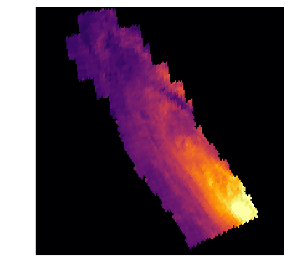

```python
gimap = np.zeros(hp.nside2npix(4096))
gimap[df_all['pix4096']] = df_all['g_i']
hp.gnomview(gimap,title='',notext=True,cbar=False,reso=0.4,nest=True,rot=(rarot,decrot,0),cmap='inferno',min=1,max=2.5)
```

### Healpix map of the brick number

We can also use our Healpix table to make a map of the PHAT bricks.

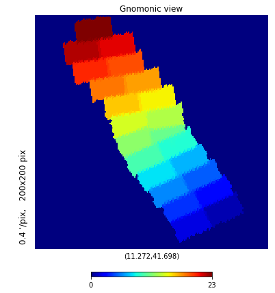

```python
brickmap = np.zeros(hp.nside2npix(4096))
brickmap[df_all['pix4096']] = df_all['brick']
hp.gnomview(brickmap,reso=0.4,nest=True,rot=(rarot,decrot,0),cmap='jet',min=0,max=23)
```

# Do a spatial query and make color-color diagrams and CMDs

Now let's do a cone search for objects within a radius of a particular position. The PHAT tables are spatially indexed to make such queries fast. We'll search within a 1 arcmin radius of the RA and Dec position that we defined earlier.

```python
query = """SELECT *
           FROM phat_v2.phot_mod WHERE q3c_radial_query(ra,dec,{0},{1},{2})
        """.format(rarot,decrot,1./60)
print(query)
```

```
SELECT *
           FROM phat_v2.phot_mod WHERE q3c_radial_query(ra,dec,11.271882914997,41.697835806211046,0.016666666666666666)
```

```python
%%time
try:
    result = qc.query(token,sql=query) # by default the result is a CSV formatted string
except Exception as e:
    print(e.message)
```

```
CPU times: user 904 ms, sys: 338 ms, total: 1.24 s
Wall time: 9.64 s
```

### Cut out bad missing values

Some of the objects returned will have missing magnitude measurements, indicated by 99's. Let's cut those out, and also select only the "good" stars in the ACS bands.

```python
df = helpers.convert(result,'pandas')
print("Number of rows:", len(df))
df_cmd = df[(df['f336w_vega']<50) & (df['f475w_vega']<50) & (df['f814w_vega']<50) & \
          (df['f475w_gst']==1) & (df['f814w_gst']==1)]
print("Number of rows:", len(df_cmd))
```

```
Returning Pandas dataframe
Number of rows: 246439
Number of rows: 97786
```

### Make color-color and CMD plots

We'll show the F475W-F814W,F336W-F475W color-color diagram, and a color-magnitude diagram. What do you notice?

```
(28.4, 22)
```

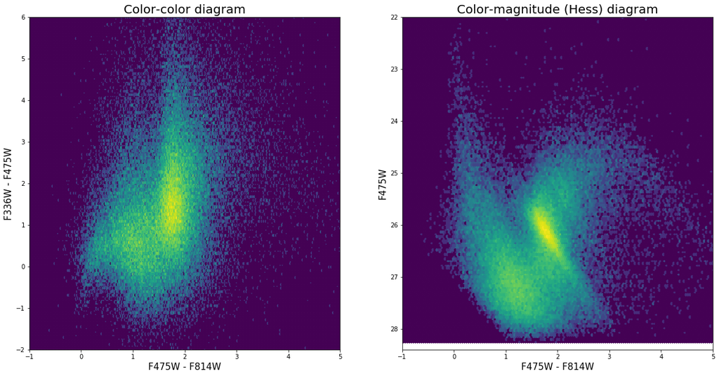

```python
# make a figure
fig = plt.figure(figsize=(20,10))
ax1 = fig.add_subplot(121)
ax2 = fig.add_subplot(122)

# color-magnitude diagram (Hess diagram)
im = ax1.hexbin(df_cmd['f475w_vega']-df_cmd['f814w_vega'],df_cmd['f336w_vega']-df_cmd['f475w_vega'], \
                gridsize=400,cmap=matplotlib.cm.viridis,norm=matplotlib.colors.LogNorm())
ax1.set_ylabel('F336W - F475W',fontsize=15)
ax1.set_xlabel('F475W - F814W',fontsize=15)
ax1.set_title('Color-color diagram',fontsize=20)
ax1.set_ylim(-2,6)
ax1.set_xlim(-1,5)


# color-magnitude diagram (Hess diagram)
im2 = ax2.hexbin(df_cmd['f475w_vega']-df_cmd['f814w_vega'],df_cmd['f475w_vega'], \
                 gridsize=200,cmap=matplotlib.cm.viridis,norm=matplotlib.colors.LogNorm())
ax2.set_xlabel('F475W - F814W',fontsize=15)
ax2.set_ylabel('F475W',fontsize=15)
ax2.set_title('Color-magnitude (Hess) diagram',fontsize=20)
ax2.set_xlim(-1,5)
ax2.set_ylim(28.4,22)
```

# Retrieving time series photometry of select objects

In this part of the notebook, we'll pick a Cepheid variable, and then query the full measurement table for the time series photometry. We'll define a couple of functions to retrieve data and make a plot.

```python
# define a function to select only measurements in one band
def get_data(df,band='F475W'):
    sel = (df['filter'] == band) & (df['magvega'] < 90)
    t = df['mjd'][sel].values
    y = df['magvega'][sel].values
    dy = df['magerr'][sel].values
    return t,y,dy # return time, magnitudes in one band, uncertainties
```

```python
# a reusable function to plot the lightcurve
def plot_raw_lightcurve(t,y,dy,title='',ax=None,lperc=13,rperc=99,color='g',ms=8):

    if ax is None:
        fig, ax = plt.subplots()

    jd0 = t.min() # modified Julian date offset
    t = t-jd0 # first date of observations = 0

    ax.errorbar(t,y,yerr=dy,marker='.',ms=ms,ls='none',color=color,lw=1,alpha=0.5,label='')

    # Main panel chores
    ax.set_xlabel('modified Julian date - %g (days)' % jd0, fontsize=20)
    ax.set_ylabel('magnitude',fontsize=20)
    ax.tick_params(labelsize=20)
    ax.invert_yaxis()
    ax.set_title(title)
```

```python
def get_folded_phase(t,best_period):

    """Fold the observation times with the best period of the variable signal."""

    # light curve over period, take the remainder (i.e. the "phase" of one period)
    phase = (t / best_period) % 1

    return phase
```

```python
def plot_folded_lightcurve(t,y,best_period,dy=None,ax=None,color='g',ms=10):

    """Plot folded lightcurve.

    Parameters
    ----------

    t, y : array
        Time and magnitude 1-d arrays

    best_period : float
        True period of the signal.

    dy : array or None
        If array, the values are the uncertainies on ``y``, and the plot will show errorbars.
        If None, the plot will have no errorbars.

    ax : instance or None
        If instance of axis class, will plot to that object. If None, will generate a new figure and axis object.
    """

    phase = get_folded_phase(t,best_period)

    if ax is None:
        fig, ax = plt.subplots()

    marker = '.'
    lw = 1
    alpha = 0.6


    if dy is not None:
        ax.errorbar(phase,y,yerr=dy,marker=marker,ms=ms,ls='none',lw=lw,color=color,alpha=alpha)
    else:
        ax.plot(phase,y,marker=marker,ms=ms,ls='none',lw=lw,color=color,alpha=alpha)

    ax.invert_yaxis()
    ax.tick_params(labelsize=20)
    ax.set_xlabel('phase (days)', fontsize=20)
    ax.set_ylabel('magnitude',fontsize=20);
```

```python
# Pick a star from Wagner-Kaiser et al. (2015)
rawk = 11.02203
decwk = 41.23451
best_period = 10.29 # days
query = """SELECT * FROM phat_v2.phot_meas WHERE q3c_radial_query(ra,dec,{0},{1},{2})""".format(rawk,decwk,0.2/3600)
print(query)
```

```
SELECT * FROM phat_v2.phot_meas WHERE q3c_radial_query(ra,dec,11.02203,41.23451,5.555555555555556e-05)
```

```python
%%time
try:
    result = qc.query(token,sql=query) # by default the result is a CSV formatted string
except Exception as e:
    print(e.message)
```

```
CPU times: user 20 ms, sys: 4 ms, total: 24 ms
Wall time: 135 ms
```

```python
df_ts = helpers.convert(result,'pandas')
print("Number of rows:", len(df_ts))
print(df_ts['filter'].unique())
print(df_ts['objid'].unique())
```

```
Returning Pandas dataframe
Number of rows: 62
['F475W' 'F275W' 'F336W' 'F814W' 'F160W' 'F110W']
['PHAT_11.0220304+41.234515']
```

```python
uid=df_ts['objid'].unique()
df_ts=df_ts[(df_ts['objid']==uid[0])]
```

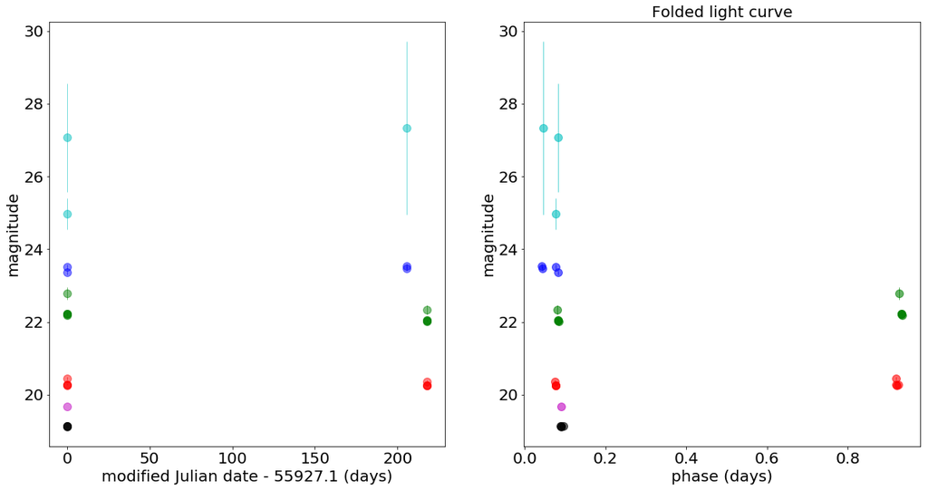

```python
colors = list('gcbrkm')
filters = ['F475W','F275W','F336W','F814W','F160W','F110W']
fig, (ax1,ax2) = plt.subplots(1,2,figsize=(20,10))
ax2.set_title('Folded light curve',fontsize=20)
for j in range(len(colors)):
   c = colors[j]
   t,y,dy = get_data(df_ts,filters[j])
   plot_raw_lightcurve(t,y,dy,title='',ax=ax1,color=c,ms=20)
   plot_folded_lightcurve(t,y,best_period,dy=dy,ax=ax2,color=c,ms=20)
```

# Resources and references

Dalcanton, J.J. et al. (2012, ApJS, 200, 18), "The Panchromatic Hubble Andromeda Treasury" http://adsabs.harvard.edu/abs/2012ApJS..200...18D

Wagner-Kaiser, R. et al. (2015, MNRAS, 451, 724), "Panchromatic Hubble Andromeda Treasury XIII: The Cepheid period-luminosity relation in M31" http://adsabs.harvard.edu/abs/2015MNRAS.451..724W

Williams, B.F. et al. (2014, ApJS, 215, 9), "The Panchromatic Hubble Andromeda Treasury. X. Ultraviolet to Infrared Photometry of 117 Million Equidistant Stars" http://adsabs.harvard.edu/abs/2014ApJS..215....9W

Williams, B.F. et al., "Reducing and Analyzing the PHAT Survey with the Cloud", ApJS, submitted